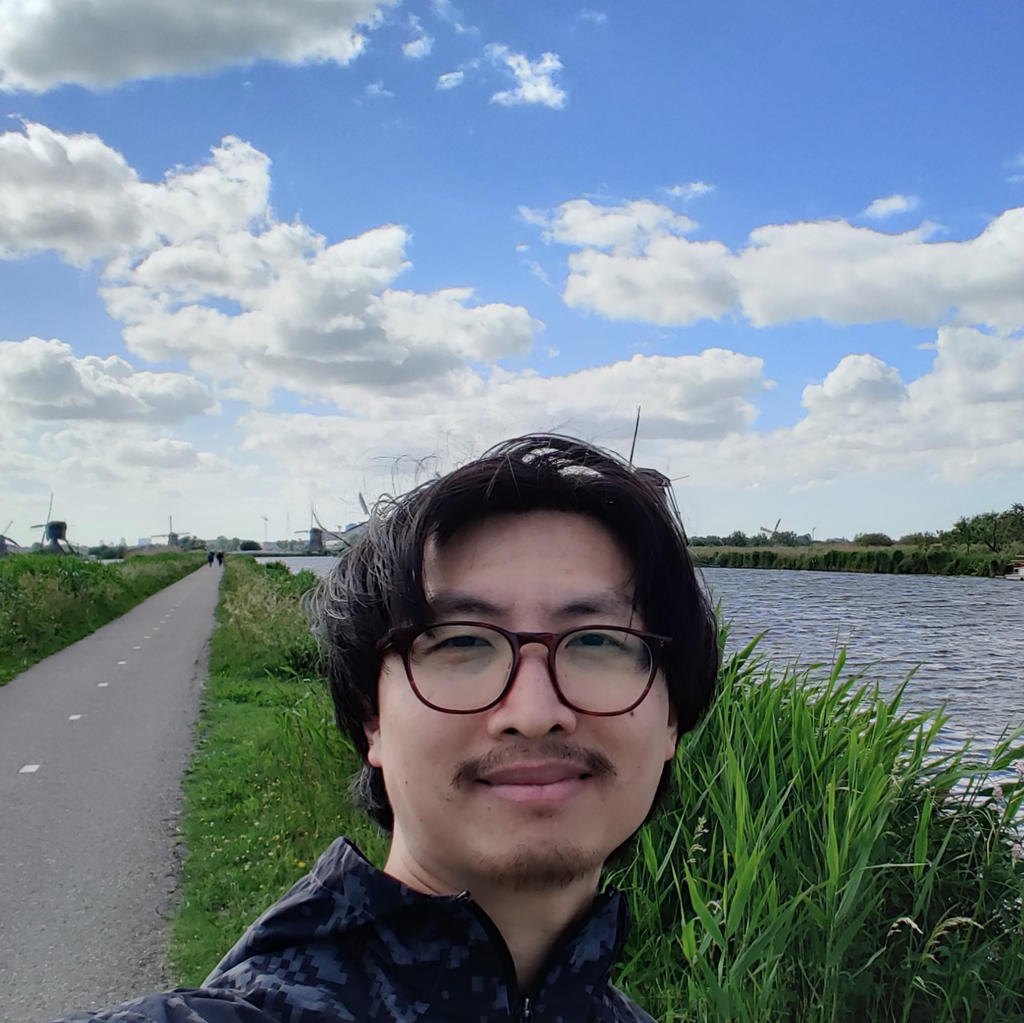

# Yibin Feng (Freddy)

## about me

Freddy recently graduated from the Master in Statistics and Data Science in the Leiden University, the Netherlands. Prior to the study, he has worked as a civil / water engineer in Hong Kong specialized in large-scale sewerage infrastructure since graduating with the bachelor degree in civil engineering. His career goal is to contribute to ambitious project dedicated to public good by leveraging his knowledge and potential in statistics and data science.

He is highly motivated to apply statistics / data science / machine learning techniques to analyze and solve problems posing interesting challenges e.g. stochastic, complex, dynamic, uncertainty etc.. That’s why he loves to learn about new techniques and new data. Just as what Richard Feynmann said, “Study hard what interests you the most in the most undisciplined, irreverent and original manner possible.”

To deliver a better solution, he believes in following principles:

- clear problem definition
- streamlined and proactive communication
- mutual trust
- roleplaying
- forward planning
- balance between time, cost and effect
- balance between exploration and exploitation
- suitable performance metric(s)/criteria
- systematic workflow
- positive feedback loop
- sensitivity analysis
- can-do spirit, result-oriented execution

He values good teamwork (1+1>2) and enjoys working in a diverse environment that encourage growth, curiosity and cultural/intellectual exchange. Apart from a positive impact, a memory worth cherishing means a lot to the motivation and satisfaction of a job.

Currently, he is living in Rotterdam. (Surprise, surprise, the portrait photo was taken at Kinderdijk!)

Read more about me in 🏋️education, 🧗experience, 👨‍🍳recent works, 🧰skills, and 😍hobbies below.

## 🏋️education

**Master in Statistics and Data Science** | 2020 - Aug 2022 |

Leiden University, The Netherlands

**Bachelor in Civil and Structural Engineering** | 2009 - 2012 |

Hong Kong University of Science and Technology, Hong Kong

## 👨‍🍳recent works

He has completed his thesis project in 2022 and graduated from the Master of Statistics and Data Science, Leiden Univeristy. The thesis focused on comparing various novel statistics modelling methods that predict progression into dementia using longitudinal data on dataset obtained from the Alzheimer’s Disease Neuroimaging Initiative study. The statistical computing was carried out in R with the used of ALICE High Performance Computing facility at Leiden University.

Recently, he has created a [flashcard app](https://ik-weet-het-niet-train-your-memory.streamlit.app/) based on the Spaced Repetition method using Streamlit (Python) to memorize Dutch words better.

During his spare time, he loves to follow the development in sports data science (mainly football) and explores approaches to extract actionable and interpretable insights from various forms of data i.e. event data, tracking data, and journal data. For example:

- passing networks
  - aggregation of passing statistics to a team-based network
- spatial control model
  - pobability model describing the tendency of a team winning the ball at certain point on the football pitch

He is also trying to build a system to optimize and automate the decision making for the Fantasy Premier League (FPL) game, in which a player needs to manage a portfolio of football players to score points based on the their events on field every game week, by modelling football events’ data generating process and searching / evaluating competing strategies.

## 🧗experience

**Assistant Engineer** | 2016 - 2020 | AECOM, Hong Kong

**Assistant Resident Engineer** | 2014 - 2016 | AECOM, Hong Kong

**Graduate Engineer** | 2012 - 2014 | AECOM, Hong Kong

After graduation from a civil engineering bachelor, Freddy joined the water engineering discipline of AECOM, one of the leading engineering consultant companies in Hong Kong.

Over the eight years in AECOM, he gained an extensive, end-to-end experience from multiple public sewerage projects that covered most types of infrastructure, including sewer, sewage pumping station ( rioolgemaal), and sewage treatment works (rioolwaterzuiveringsinstallatie).

The planning and design of the [Yuen Long Effluent Polishing Plant](http://www.hkengineer.org.hk/issue/vol50-jan2022/cover_story/) (YLEPP) is one of the vivid highlights in his engineering career. The project aims at replacing an aging sewage treatment works to support the future population growth in the Yuen Long district of Hong Kong. As a part of the project management and core design team, he collaborated with professionals from several disciplines, including electrical & mechanical engineers, sewage & sludge treatment engineers, geotechnical engineers, architects, and stakeholders to come up with an integrated design to overcome several non-trivial challenges and achieve the design visions of being green, smart, and resilient.

The notion of smart design above, as materialized in the application of Building Information Modelling (BIM) and the pursuit to leverage artificial intelligence to optimize the future plant operation / maintenance, eventually inspired him to explore the vast universe of data science - one of the key components for digital twins and [smart cities](https://en.wikipedia.org/wiki/Smart_city).

## 🧰skills

Statistics, data science, machine learning:

- coding language | R, Python
- statistics | generalized linear models, mixed models, survival analysis, Bayesian models
- supervised learning | random forest, boosting, SVM
- unsupervised learning | principal component analysis, clustering techniques
- deep learning, reinforcement learning | Py - TensorFlow, PyTorch
- visualization | R - ggplot2; Py - matplotlib, seaborn
- interactive | R - shiny; Py - streamlit
- database | SQL
- utils | Git, Slurm, Docker
- other | AutoML, social network analysis, spatial analysis

Engineering:

- hydraulic and hydrologic modeling | Infoworks ICM
- building Information Modeling | Revit
- engineering contract | NEC4

Other:

- MS Office suite

Language:

- Cantonese 廣東話 (mother tongue)
- Mandarin (fluent)
- English (fluent)
- Nederlands (A1->A2/B1)

## 😍hobbies

- architecture
- games: boardgames, simulation, city planning
- exploring places
- Japanese anime: Akira, Ghost in the Shell, Gundam series
- language: Dutch language (and finish reading Van Nul Tot Nu)
- museums: art, culture, history, science
- music: jazz, Tokyo Jihen, learning 🎸
- reading
- sport: ⚽, 🚴, sport analytics
- water infrastructure

🎉 You made it to the end. Thanks for your patience and have a nice day!

Feel free to DM me at linkedin if you wish to know more.